# TP2_LACHEHEB

Mohamed Salah LACHEHEB

2022-10-20

## Importation de jeux de données :

**Exercice 1:**  
1

```r
#Importation des données à partir du fichier statlab.txt
df=scan("statlab.txt")
df=matrix(df,ncol=19,byrow=T)

#Conversion en dataframe
df=data.frame(df)

# Gérer les noms des variables
varname=c("sexenf","gsenf","tenf_n","penf_n", "tenf_10","penf_10",
"gsmere","agem_n","pmere_n","consm_n","tmere",
"pmere_10", "consm_10","agep_n", "consp_n","tpere","ppere_10",
"revf_n","revf_10")
colnames(df)=varname

#Afficher les 5 premiere lignes pour voir à quoi ressemble notre DF
df[1:5,]
```

```
##   sexenf gsenf tenf_n penf_n tenf_10 penf_10 gsmere agem_n pmere_n consm_n
## 1      1     6   19.5    7.0    53.6      88      6     18     135       4
## 2      1     2   19.0    5.4    49.0      51      1     18      99       5
## 3      1     3   20.3    7.3    51.3      58      2     20     121       2
## 4      1     9   18.5    7.5    50.5      60      6     20     140       4
## 5      1     5   20.0    6.3    52.4      66      6     20     102       2
##   tmere pmere_10 consm_10 agep_n consp_n tpere ppere_10 revf_n revf_10
## 1  61.8      123        1     26       4  71.8      196     42     112
## 2  64.8      107        2     22       4  70.0      145     37     140
## 3  62.0      132        1     21       5  71.0      165     54     114
## 4  65.4      144        5     20       4  71.0      190     86     180
## 5  64.0      120        1     21       4  70.5      150     89     150
```

#### 2

2.1

```r
# Convertion des tailles en cm
df$tenf_n = 2.54 * df$tenf_n
df$tenf_10 = 2.54 * df$tenf_10
df$tmere = 2.54 * df$tmere
df$tpere = 2.54 * df$tpere

# Convertion des poids en kg
df$penf_n = 0.454 * df$penf_n
df$penf_10 = 0.454 * df$penf_10
df$pmere_n = 0.454 * df$pmere_n
df$pmere_10 = 0.454 * df$pmere_10
df$ppere_10 = 0.454 * df$ppere_10


#Afficher les 5 premiere lignes pour voir à quoi ressemble notre DF
df[1:5,]
```

```
##   sexenf gsenf tenf_n penf_n tenf_10 penf_10 gsmere agem_n pmere_n consm_n
## 1      1     6 49.530 3.1780 136.144  39.952      6     18  61.290       4
## 2      1     2 48.260 2.4516 124.460  23.154      1     18  44.946       5
## 3      1     3 51.562 3.3142 130.302  26.332      2     20  54.934       2
## 4      1     9 46.990 3.4050 128.270  27.240      6     20  63.560       4
## 5      1     5 50.800 2.8602 133.096  29.964      6     20  46.308       2
##     tmere pmere_10 consm_10 agep_n consp_n   tpere ppere_10 revf_n revf_10
## 1 156.972   55.842        1     26       4 182.372   88.984     42     112
## 2 164.592   48.578        2     22       4 177.800   65.830     37     140
## 3 157.480   59.928        1     21       5 180.340   74.910     54     114
## 4 166.116   65.376        5     20       4 180.340   86.260     86     180
## 5 162.560   54.480        1     21       4 179.070   68.100     89     150
```

2.2 Codage sexe:

```r
df$sexenf[df$sexenf == 1] = "garcon"
df$sexenf[df$sexenf == 2] = "fille"

#Afficher les 5 premiere lignes pour voir à quoi ressemble notre DF
df[1:5,]
```

```
##   sexenf gsenf tenf_n penf_n tenf_10 penf_10 gsmere agem_n pmere_n consm_n
## 1 garcon     6 49.530 3.1780 136.144  39.952      6     18  61.290       4
## 2 garcon     2 48.260 2.4516 124.460  23.154      1     18  44.946       5
## 3 garcon     3 51.562 3.3142 130.302  26.332      2     20  54.934       2
## 4 garcon     9 46.990 3.4050 128.270  27.240      6     20  63.560       4
## 5 garcon     5 50.800 2.8602 133.096  29.964      6     20  46.308       2
##     tmere pmere_10 consm_10 agep_n consp_n   tpere ppere_10 revf_n revf_10
## 1 156.972   55.842        1     26       4 182.372   88.984     42     112
## 2 164.592   48.578        2     22       4 177.800   65.830     37     140
## 3 157.480   59.928        1     21       5 180.340   74.910     54     114
## 4 166.116   65.376        5     20       4 180.340   86.260     86     180
## 5 162.560   54.480        1     21       4 179.070   68.100     89     150
```

2.3 Consommation de cigarettes:

```r
csCig=c('nonfum','1a2cig','3a10cig','10a20cig','+de20cig','inc')

# Consommation

for(i in 1:length(csCig)){
df$consm_n[df$consm_n==i]=csCig[i]
df$consm_10[df$consm_10 == i] = csCig[i]
df$consp_n[df$consp_n==i]=csCig[i]
}


#Afficher les 5 premiere lignes pour voir à quoi ressemble notre DF
df[1:5,]
```

```
##   sexenf gsenf tenf_n penf_n tenf_10 penf_10 gsmere agem_n pmere_n  consm_n
## 1 garcon     6 49.530 3.1780 136.144  39.952      6     18  61.290 10a20cig
## 2 garcon     2 48.260 2.4516 124.460  23.154      1     18  44.946 +de20cig
## 3 garcon     3 51.562 3.3142 130.302  26.332      2     20  54.934   1a2cig
## 4 garcon     9 46.990 3.4050 128.270  27.240      6     20  63.560 10a20cig
## 5 garcon     5 50.800 2.8602 133.096  29.964      6     20  46.308   1a2cig
##     tmere pmere_10 consm_10 agep_n  consp_n   tpere ppere_10 revf_n revf_10
## 1 156.972   55.842   nonfum     26 10a20cig 182.372   88.984     42     112
## 2 164.592   48.578   1a2cig     22 10a20cig 177.800   65.830     37     140
## 3 157.480   59.928   nonfum     21 +de20cig 180.340   74.910     54     114
## 4 166.116   65.376 +de20cig     20 10a20cig 180.340   86.260     86     180
## 5 162.560   54.480   nonfum     21 10a20cig 179.070   68.100     89     150
```

2.4 LEs variables qualitatives

```r
str (df$sexenf)
```

```
##  chr [1:115] "garcon" "garcon" "garcon" "garcon" "garcon" "garcon" "garcon" ...
```

```r
is.character(df$sexenf)
```

```
## [1] TRUE
```

```r
is.factor( df$sexenf )
```

```
## [1] FALSE
```

```r
summary(df$sexenf)
```

```
##    Length     Class      Mode
##       115 character character
```

- Dans ce cas R consider sexenf comme caractère donc on doit le convertir en factor pour que R le consider comme une variable qualitative

```r
df$sexenf = factor(df$sexenf)
is.factor(df$sexenf)
```

```
## [1] TRUE
```

```r
str (df$sexenf)
```

```
##  Factor w/ 2 levels "fille","garcon": 2 2 2 2 2 2 2 2 2 2 ...
```

```r
summary(df$sexenf)
```

```
##  fille garcon
##     46     69
```

- Dans ce cas R considere sexenf comme une variables Qualitative qui peut prendre deux valeur : “fille” ou “garcon”

```r
var_qual = c(2, 7, 10, 13 ,15) # le 1 on l'a deja fait

for( i in var_qual){
  df[,i] = factor(df[,i])
}
summary(df[,var_qual])
```

```
##      gsenf    gsmere     consm_n       consm_10      consp_n
##  5      :40   1:12   +de20cig: 5   +de20cig:15   +de20cig:19
##  6      :33   2: 6   10a20cig:34   10a20cig:24   10a20cig:46
##  7      :11   3: 1   1a2cig  :25   1a2cig  :16   1a2cig  :10
##  9      :10   5:44   3a10cig : 3   3a10cig : 5   3a10cig : 4
##  1      : 7   6:39   nonfum  :48   nonfum  :55   nonfum  :36
##  2      : 7   7:12
##  (Other): 7   9: 1
```

```r
quali=df[,var_qual]
```

2.5 Par défaut le nombre max des variables qualitatives autorisé par R = 7 c’est pour cela que pour la variable gsenf il afficher other donc dans cette partie on va lui autoriser jusqu’à 10 variables

```r
summary(df)
```

```
##     sexenf       gsenf        tenf_n          penf_n         tenf_10
##  fille :46   5      :40   Min.   :43.18   Min.   :1.771   Min.   :124.0
##  garcon:69   6      :33   1st Qu.:50.80   1st Qu.:2.928   1st Qu.:132.6
##              7      :11   Median :52.07   Median :3.360   Median :136.1
##              9      :10   Mean   :51.88   Mean   :3.392   Mean   :136.0
##              1      : 7   3rd Qu.:53.34   3rd Qu.:3.768   3rd Qu.:139.8
##              2      : 7   Max.   :58.42   Max.   :6.356   Max.   :151.4
##              (Other): 7
##     penf_10      gsmere     agem_n         pmere_n           consm_n
##  Min.   :23.15   1:12   Min.   :15.00   Min.   : 43.58   +de20cig: 5
##  1st Qu.:27.47   2: 6   1st Qu.:24.00   1st Qu.: 51.30   10a20cig:34
##  Median :31.78   3: 1   Median :27.00   Median : 56.75   1a2cig  :25
##  Mean   :32.55   5:44   Mean   :27.53   Mean   : 59.63   3a10cig : 3
##  3rd Qu.:36.09   6:39   3rd Qu.:32.00   3rd Qu.: 63.33   nonfum  :48
##  Max.   :57.20   7:12   Max.   :43.00   Max.   :113.50
##                  9: 1
##      tmere          pmere_10          consm_10      agep_n          consp_n
##  Min.   :148.3   Min.   : 38.59   +de20cig:15   Min.   :20.00   +de20cig:19
##  1st Qu.:160.1   1st Qu.: 55.16   10a20cig:24   1st Qu.:26.00   10a20cig:46
##  Median :164.1   Median : 60.84   1a2cig  :16   Median :29.00   1a2cig  :10
##  Mean   :164.1   Mean   : 64.11   3a10cig : 5   Mean   :30.57   3a10cig : 4
##  3rd Qu.:167.8   3rd Qu.: 69.23   nonfum  :55   3rd Qu.:35.00   nonfum  :36
##  Max.   :177.8   Max.   :115.77                 Max.   :50.00
##
##      tpere          ppere_10          revf_n         revf_10
##  Min.   :158.2   Min.   : 49.49   Min.   : 14.0   Min.   : 21.0
##  1st Qu.:172.8   1st Qu.: 72.64   1st Qu.: 54.0   1st Qu.:110.0
##  Median :179.1   Median : 80.81   Median : 72.0   Median :150.0
##  Mean   :178.9   Mean   : 82.31   Mean   : 76.1   Mean   :156.5
##  3rd Qu.:185.4   3rd Qu.: 90.80   3rd Qu.: 93.0   3rd Qu.:190.0
##  Max.   :198.1   Max.   :128.94   Max.   :250.0   Max.   :500.0
##
```

```r
summary(df, maxsum = 10)
```

```
##     sexenf   gsenf      tenf_n          penf_n         tenf_10
##  fille :46   1: 7   Min.   :43.18   Min.   :1.771   Min.   :124.0
##  garcon:69   2: 7   1st Qu.:50.80   1st Qu.:2.928   1st Qu.:132.6
##              3: 2   Median :52.07   Median :3.360   Median :136.1
##              4: 1   Mean   :51.88   Mean   :3.392   Mean   :136.0
##              5:40   3rd Qu.:53.34   3rd Qu.:3.768   3rd Qu.:139.8
##              6:33   Max.   :58.42   Max.   :6.356   Max.   :151.4
##              7:11
##              8: 4
##              9:10
##     penf_10      gsmere     agem_n         pmere_n           consm_n
##  Min.   :23.15   1:12   Min.   :15.00   Min.   : 43.58   +de20cig: 5
##  1st Qu.:27.47   2: 6   1st Qu.:24.00   1st Qu.: 51.30   10a20cig:34
##  Median :31.78   3: 1   Median :27.00   Median : 56.75   1a2cig  :25
##  Mean   :32.55   5:44   Mean   :27.53   Mean   : 59.63   3a10cig : 3
##  3rd Qu.:36.09   6:39   3rd Qu.:32.00   3rd Qu.: 63.33   nonfum  :48
##  Max.   :57.20   7:12   Max.   :43.00   Max.   :113.50
##                  9: 1
##
##
##      tmere          pmere_10          consm_10      agep_n          consp_n
##  Min.   :148.3   Min.   : 38.59   +de20cig:15   Min.   :20.00   +de20cig:19
##  1st Qu.:160.1   1st Qu.: 55.16   10a20cig:24   1st Qu.:26.00   10a20cig:46
##  Median :164.1   Median : 60.84   1a2cig  :16   Median :29.00   1a2cig  :10
##  Mean   :164.1   Mean   : 64.11   3a10cig : 5   Mean   :30.57   3a10cig : 4
##  3rd Qu.:167.8   3rd Qu.: 69.23   nonfum  :55   3rd Qu.:35.00   nonfum  :36
##  Max.   :177.8   Max.   :115.77                 Max.   :50.00
##
##
##
##      tpere          ppere_10          revf_n         revf_10
##  Min.   :158.2   Min.   : 49.49   Min.   : 14.0   Min.   : 21.0
##  1st Qu.:172.8   1st Qu.: 72.64   1st Qu.: 54.0   1st Qu.:110.0
##  Median :179.1   Median : 80.81   Median : 72.0   Median :150.0
##  Mean   :178.9   Mean   : 82.31   Mean   : 76.1   Mean   :156.5
##  3rd Qu.:185.4   3rd Qu.: 90.80   3rd Qu.: 93.0   3rd Qu.:190.0
##  Max.   :198.1   Max.   :128.94   Max.   :250.0   Max.   :500.0
##
##
##
```

#### 2.2 Echantillonnage:

```r
set.seed(6)

n0 = 102
n_lignes = nrow(df)
# tirage sans remise de 102 lignes au hazard parmi les lignes initiales
n2 = sample(1: n_lignes, n0, replace = F)

# Choisir les données de l'echantillon depuis le df
df = df[n2,]

#Afficher les 5 premiere lignes pour voir à quoi ressemble notre DF
df[1:5,]
```

```
##    sexenf gsenf tenf_n penf_n tenf_10 penf_10 gsmere agem_n pmere_n  consm_n
## 53 garcon     6  57.15 4.9032 134.366  40.406      6     35  70.370   nonfum
## 10 garcon     5  53.34 3.2688 134.620  39.952      5     21  52.664   nonfum
## 45 garcon     7  52.07 3.1326 135.890  29.964      5     31  59.020 10a20cig
## 78  fille     6  44.45 2.0430 138.176  35.412      6     25  90.800 10a20cig
## 56 garcon     2  48.26 2.7240 132.588  27.240      6     37  57.658   nonfum
##      tmere pmere_10 consm_10 agep_n  consp_n  tpere ppere_10 revf_n revf_10
## 53 166.624   78.088   nonfum     35 10a20cig 167.64   90.800     55     156
## 10 163.322   57.204 10a20cig     25   nonfum 170.18   65.830     63     156
## 45 168.910   64.468 10a20cig     32   nonfum 181.61   86.260    139     224
## 78 168.148   95.794 +de20cig     29 10a20cig 182.88   78.088     76      88
## 56 161.798   74.456   nonfum     39 10a20cig 167.64   69.008     99     280
```

## 3. Analyse univariée des variables quantitavies:

**Exercice 2:**

```r
summary(df)
```

```
##     sexenf       gsenf        tenf_n          penf_n         tenf_10
##  fille :41   5      :38   Min.   :43.18   Min.   :1.771   Min.   :124.0
##  garcon:61   6      :28   1st Qu.:50.80   1st Qu.:2.906   1st Qu.:132.6
##              7      : 9   Median :52.07   Median :3.360   Median :135.9
##              9      : 9   Mean   :51.95   Mean   :3.411   Mean   :136.1
##              1      : 7   3rd Qu.:53.34   3rd Qu.:3.757   3rd Qu.:139.9
##              2      : 6   Max.   :58.42   Max.   :6.356   Max.   :151.4
##              (Other): 5
##     penf_10      gsmere     agem_n         pmere_n           consm_n
##  Min.   :23.15   1:11   Min.   :15.00   Min.   : 44.04   +de20cig: 5
##  1st Qu.:27.69   2: 5   1st Qu.:24.00   1st Qu.: 50.96   10a20cig:31
##  Median :32.01   3: 1   Median :26.50   Median : 56.75   1a2cig  :21
##  Mean   :32.69   5:41   Mean   :27.33   Mean   : 59.53   3a10cig : 2
##  3rd Qu.:35.75   6:33   3rd Qu.:31.75   3rd Qu.: 63.56   nonfum  :43
##  Max.   :57.20   7:11   Max.   :41.00   Max.   :113.50
##                  9: 0
##      tmere          pmere_10          consm_10      agep_n          consp_n
##  Min.   :148.3   Min.   : 38.59   +de20cig:13   Min.   :20.00   +de20cig:18
##  1st Qu.:160.3   1st Qu.: 55.05   10a20cig:22   1st Qu.:26.00   10a20cig:40
##  Median :164.1   Median : 61.06   1a2cig  :16   Median :29.00   1a2cig  : 8
##  Mean   :164.1   Mean   : 63.88   3a10cig : 3   Mean   :30.41   3a10cig : 4
##  3rd Qu.:167.8   3rd Qu.: 69.01   nonfum  :48   3rd Qu.:35.00   nonfum  :32
##  Max.   :175.5   Max.   :108.05                 Max.   :50.00
##
##      tpere          ppere_10          revf_n          revf_10
##  Min.   :158.2   Min.   : 49.49   Min.   : 14.00   Min.   : 21.0
##  1st Qu.:172.8   1st Qu.: 72.98   1st Qu.: 51.00   1st Qu.:110.0
##  Median :180.1   Median : 80.81   Median : 72.50   Median :148.0
##  Mean   :178.9   Mean   : 82.37   Mean   : 76.75   Mean   :153.1
##  3rd Qu.:185.4   3rd Qu.: 90.80   3rd Qu.: 95.75   3rd Qu.:184.8
##  Max.   :198.1   Max.   :128.94   Max.   :250.00   Max.   :500.0
##
```

**Exercice 3:**  
Dans cette partie on va disperser les variables quantitatives des variables qualitatives:

```r
quanti=df[,-c(1,2,7,10,13,15)]
quali=df[,c(1,2,7,10,13,15)]
```

**Exercice 4:**

```r
# Afficher la moyenne des variables quantitavies
apply(quanti, 2, mean)
```

```
##     tenf_n     penf_n    tenf_10    penf_10     agem_n    pmere_n      tmere
##  51.950471   3.411231 136.124078  32.692451  27.333333  59.531863 164.074039
##   pmere_10     agep_n      tpere   ppere_10     revf_n    revf_10
##  63.876020  30.411765 178.883235  82.365392  76.745098 153.098039
```

- Quelques interprétations: depuis les stats reçues on pourra dire que :
  - La taille d’un enfant à son naissance = 51.95 cm en moyenne
  - Le poids d’un enfant à son naissance = 3.41 kg en moyenne
  - Les revenues familliale à la naissance de l’enfant en moyenne = 76.74

- Donne le 1ér décile :  
* Pour toute variables : 10% de la population ont une valeur inferieur a ce qui va être afficher

```r
apply(quanti, 2, function(x)quantile(x,0.1))
```

```
##   tenf_n   penf_n  tenf_10  penf_10   agem_n  pmere_n    tmere pmere_10
##  48.2600   2.6786 127.7620  26.3320  20.1000  47.6700 157.2514  51.3928
##   agep_n    tpere ppere_10   revf_n  revf_10
##  23.0000 167.6400  67.1920  37.0000  78.0000
```

- Donner le 1er décile et le 9eme décile :  
* Pour toute variables : 10% ont une valeur inferieur au premier decile  
* Pour toute variables : 90% ont une valeur inferieur au neuvieme decile

```r
apply(quanti,2,function(x)quantile(x, probs=c(0.1, 0.9)))
```

```
##     tenf_n  penf_n  tenf_10 penf_10 agem_n pmere_n    tmere pmere_10 agep_n
## 10%  48.26 2.67860 127.7620  26.332   20.1   47.67 157.2514  51.3928     23
## 90%  55.88 4.26306 145.2372  39.952   35.0   72.64 170.8912  79.4046     38
##      tpere ppere_10 revf_n revf_10
## 10% 167.64  67.1920   37.0    78.0
## 90% 187.96  99.5168  115.9   219.5
```

- Pour toute variables : Donner le 1er, 4eme, 7eme et le 10eme décile

```r
apply(quanti, 2,function(x)quantile(x, probs=seq(0.1, by=0.3)))
```

```
##      tenf_n  penf_n tenf_10 penf_10 agem_n pmere_n    tmere pmere_10 agep_n
## 10%   48.26 2.67860 127.762 26.3320   20.1   47.67 157.2514  51.3928     23
## 40%   50.80 3.26880 134.366 29.9640   25.0   54.48 162.5600  58.5660     27
## 70%   53.34 3.65016 138.176 34.8218   30.0   61.29 167.3860  66.1478     35
## 100%  58.42 6.35600 151.384 57.2040   41.0  113.50 175.5140 108.0520     50
##       tpere ppere_10 revf_n revf_10
## 10%  167.64   67.192   37.0      78
## 40%  177.80   77.180   64.4     132
## 70%  182.88   86.260   90.0     180
## 100% 198.12  128.936  250.0     500
```

2. Caracteristique de dispersion
- Cette methode va nous permetre d’afficher l’écart-type et la moyenne respectivement pour chaque variables quantitatives de notre df

```r
ecart_type = apply(quanti, 2, sd)
ecart_type
```

```
##     tenf_n     penf_n    tenf_10    penf_10     agem_n    pmere_n      tmere
##  2.9183923  0.6850199  6.1560280  6.1419288  5.6135150 12.7622567  5.4173474
##   pmere_10     agep_n      tpere   ppere_10     revf_n    revf_10
## 12.7911856  6.4567916  7.7555953 13.9214928 37.7922110 69.4999836
```

```r
moyenne = apply(quanti, 2, mean)
moyenne
```

```
##     tenf_n     penf_n    tenf_10    penf_10     agem_n    pmere_n      tmere
##  51.950471   3.411231 136.124078  32.692451  27.333333  59.531863 164.074039
##   pmere_10     agep_n      tpere   ppere_10     revf_n    revf_10
##  63.876020  30.411765 178.883235  82.365392  76.745098 153.098039
```

- Le coefficient de variation

```r
CVx = ecart_type / moyenne
CVx
```

```
##     tenf_n     penf_n    tenf_10    penf_10     agem_n    pmere_n      tmere
## 0.05617644 0.20081308 0.04522365 0.18786994 0.20537250 0.21437691 0.03301770
##   pmere_10     agep_n      tpere   ppere_10     revf_n    revf_10
## 0.20025020 0.21231230 0.04335563 0.16902114 0.49243811 0.45395737
```

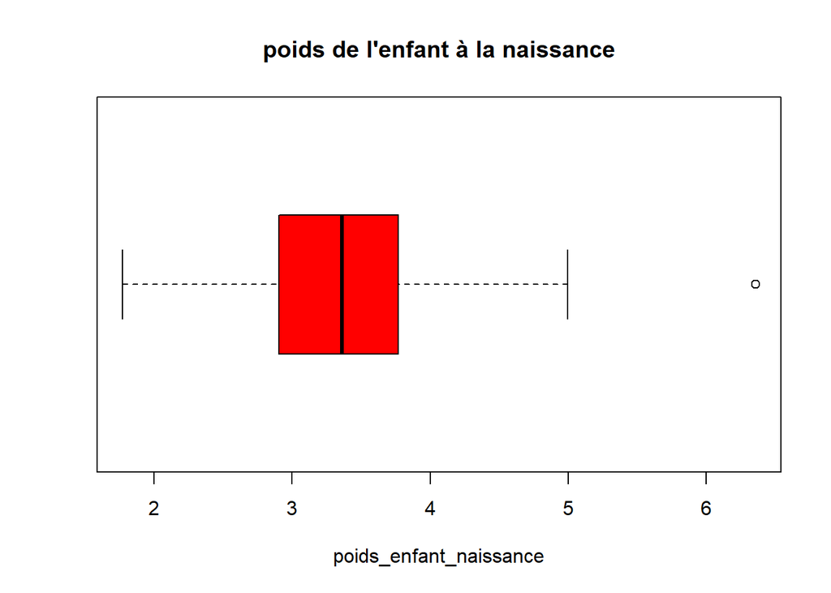

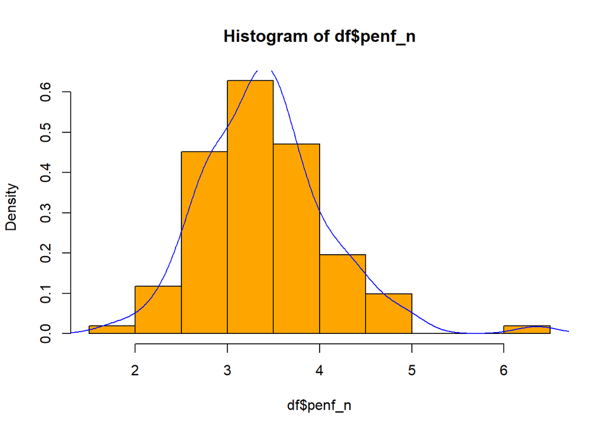

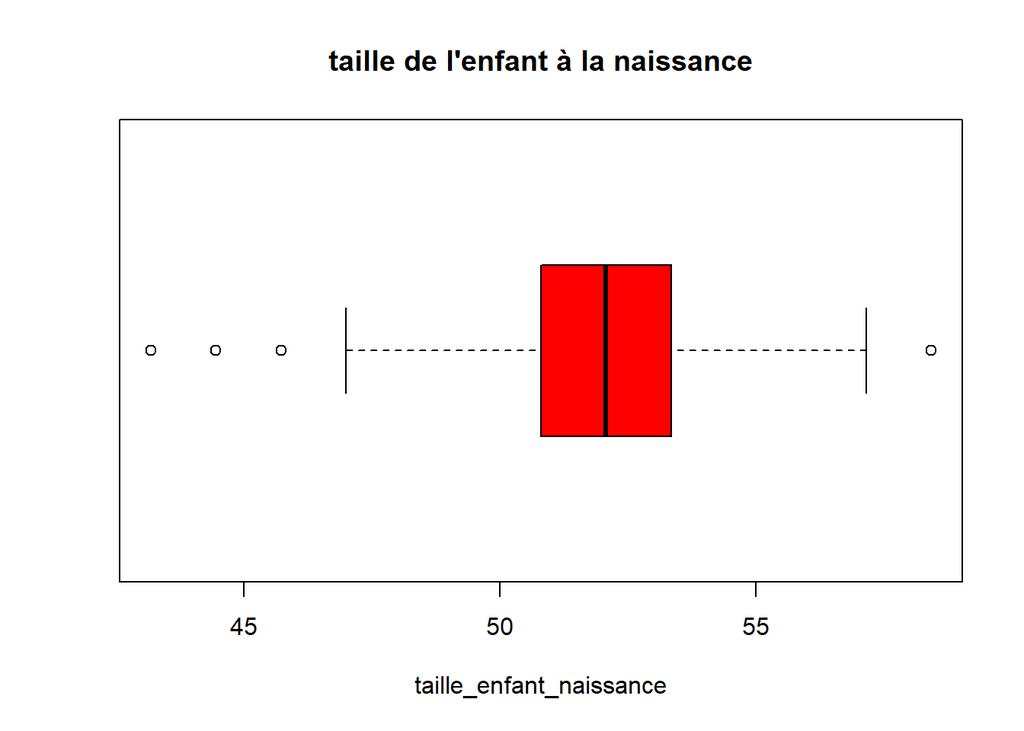

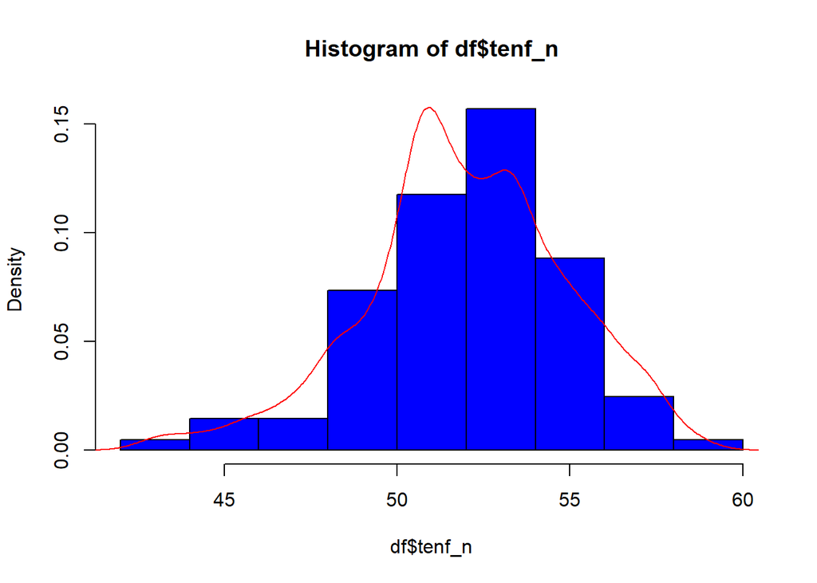

*Interpretations* :  
* Depuis le boxplot on peut voir que 25% des enfants mesure moins de 50,5 cm à leurs naissances, 75% ont moins de 53,3 cm et 50% ont plus ou moins de 51,95 cm, comme on peut bien remarqué qu’il y’a plusieurs valeurs extremes des deux cotés, la distribution est symétrique.  
* Depuis l’Hisogramme on peut dire que la distribution est bimodale tel que mode1 = 50,6 et mode2 = 54

**3ème variables : “agem_n”**

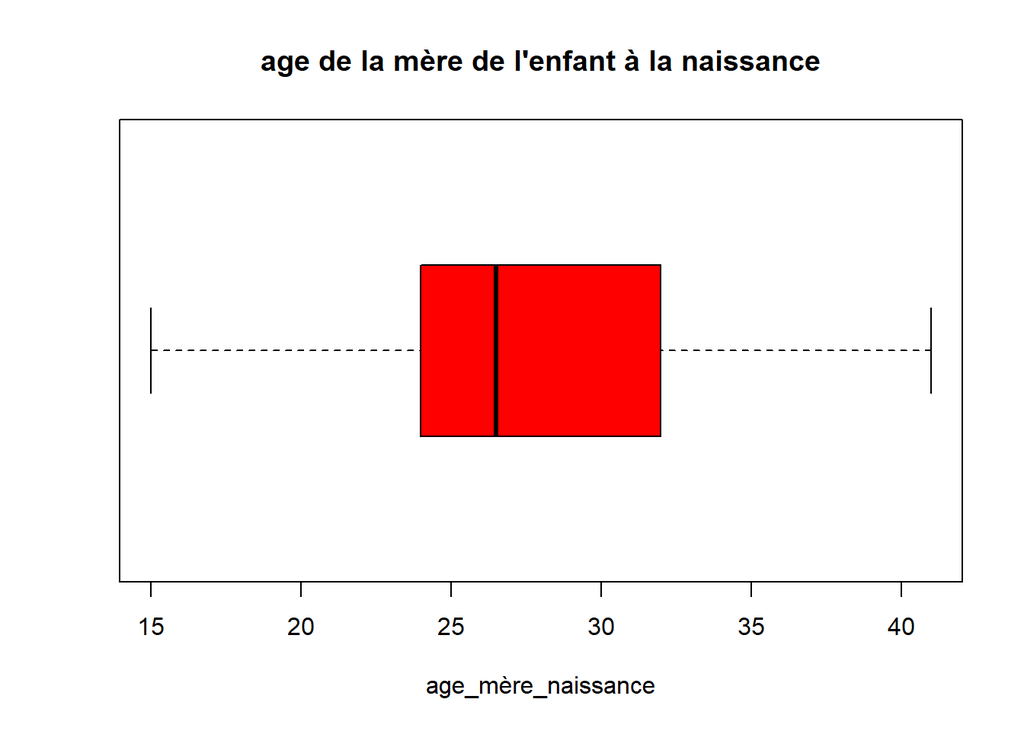

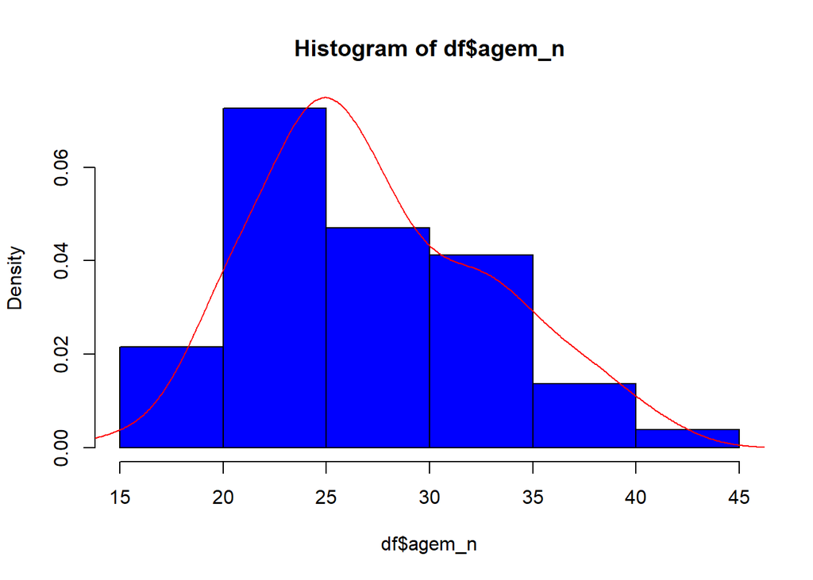

*Interpretations* :  
* Depuis le boxplot on peut voir que 25% des mères sont agée de 24 ans à la naissance, 75% ont moins de 32,5 ans et 50% ont plus ou moins de 26 ans, la distribution est non symétrique.  
* Depuis l’Hisogramme on peut dire que la distribution est unimodale tel que le mode = 25 ans

**4ème variables : “agep_n”**

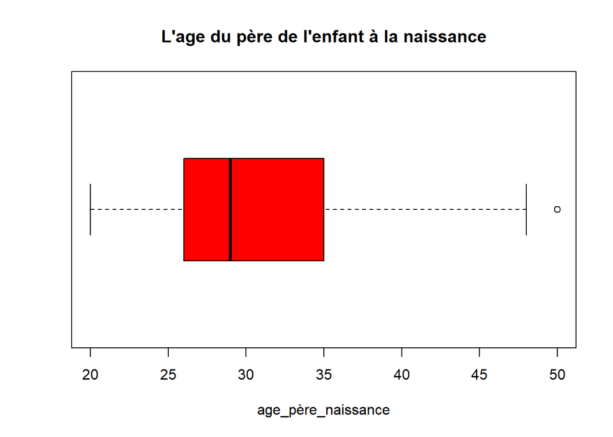

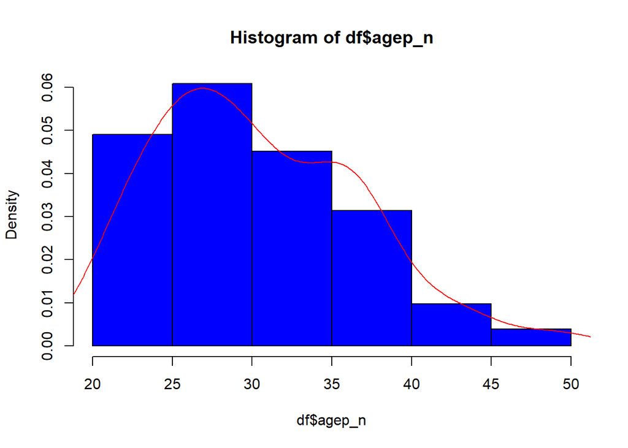

*Interpretations* :  
* Depuis le boxplot on peut voir que moins de 25% pères ont agés de 26 ans à la naissance de l’enfant , 75% ont moins de 35 ans et 50% ont plus ou moins de 29 ans, et la disribution est non symétrique.  
* Depuis l’Hisogramme on peut dire que la distribution est bimodale 1er mode = 26ans, 2eme mode = 35

## 4. Analyse univariées des variables qualitatives

Les caractéristiques numériques :

```r
# Effectif de la variable sexe enfant
summary(df$sexenf)
```

```
##  fille garcon
##     41     61
```

```r
# les effectids de toutes les variables qualitatives
summary(quali,maxsum=9)
```

```
##     sexenf   gsenf  gsmere     consm_n       consm_10      consp_n
##  fille :41   1: 7   1:11   +de20cig: 5   +de20cig:13   +de20cig:18
##  garcon:61   2: 6   2: 5   10a20cig:31   10a20cig:22   10a20cig:40
##              3: 1   3: 1   1a2cig  :21   1a2cig  :16   1a2cig  : 8
##              4: 0   5:41   3a10cig : 2   3a10cig : 3   3a10cig : 4
##              5:38   6:33   nonfum  :43   nonfum  :48   nonfum  :32
##              6:28   7:11
##              7: 9   9: 0
##              8: 4
##              9: 9
```

```r
# Les proportions
proportions = table(df$sexenf)/nrow(df)
proportions
```

```
##
##     fille    garcon
## 0.4019608 0.5980392
```

##Des graphiques

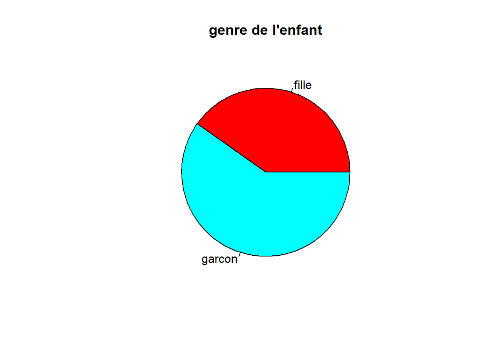

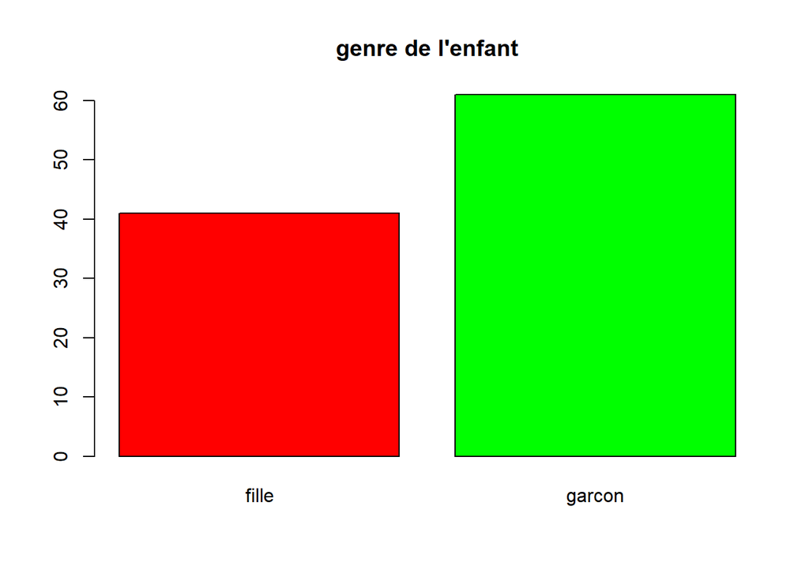

*Interpretations* :  
Dans l’echantillon sur lequel on travail on peut remarqué qu’on a 60% des données concernent les garçons et 40% concerne les filles  
**Exercice 6:**  
* Consomation de cigarette par la mère 10 ans aprés la naissance

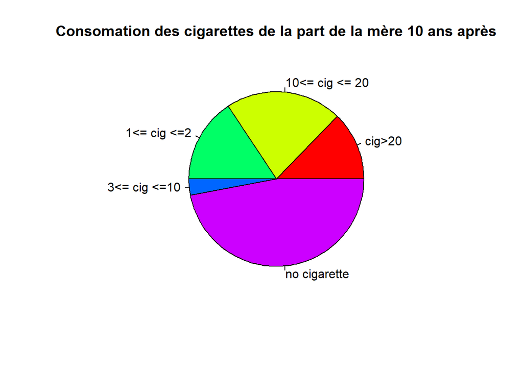

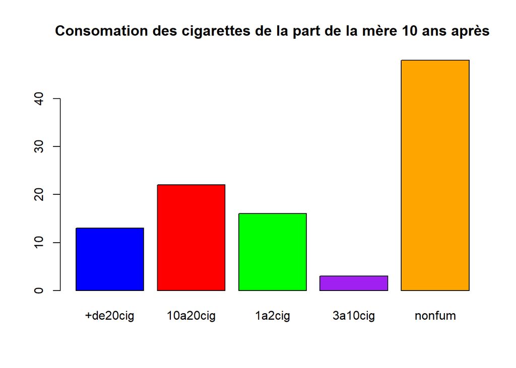

*Interpretations* :  
Presque 50% des mères ne fument pas, l’autre pourcentage se partage principalement entre celles qui fument : “entre 1 et 2”, “entre 10 et 20” et ” plus de 20” cigarettes, une petite population fume “entre 3 et 10” cigarettes.

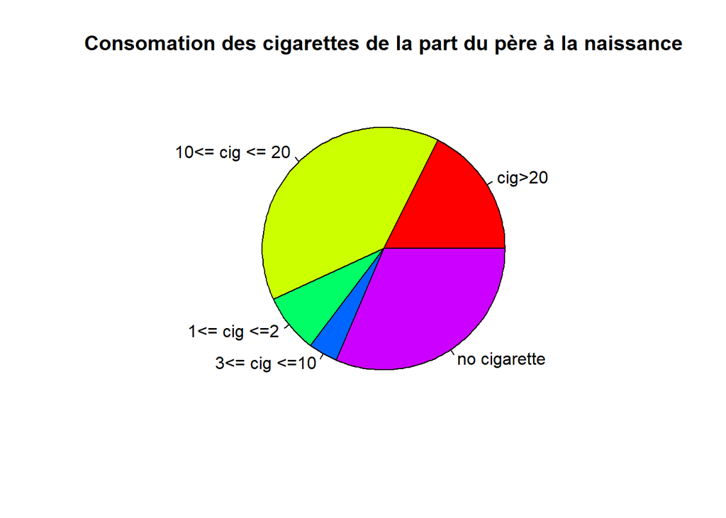

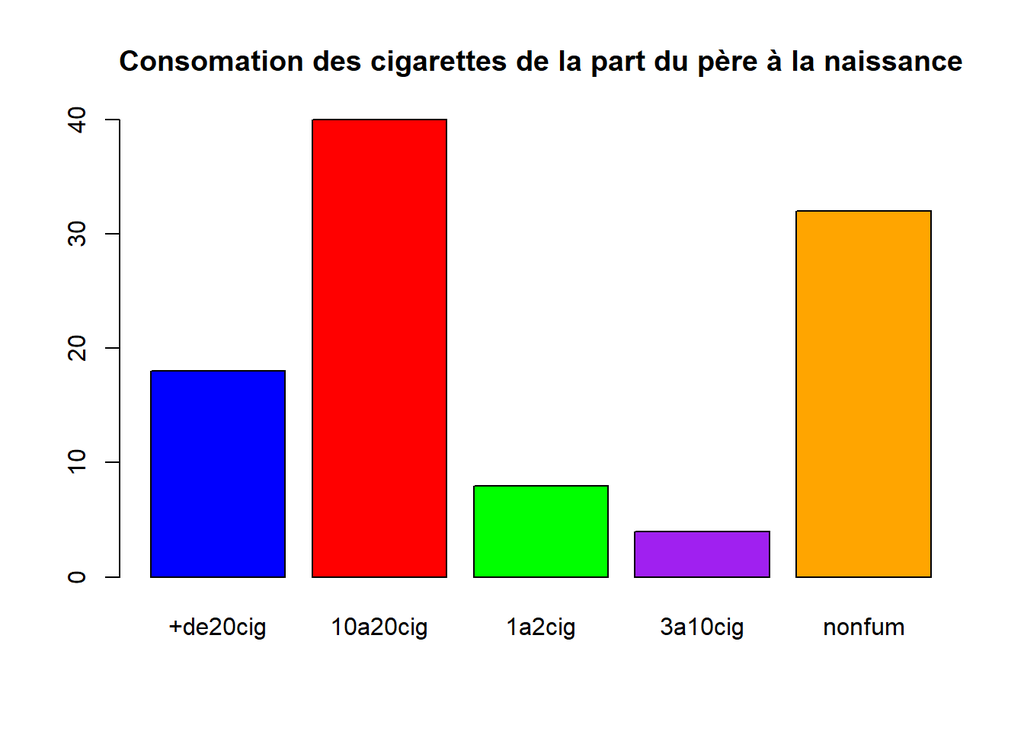

*Interpretations* :  
Par contre pour les pères, on trouvent qu’un grand nombre fument “entre 10 et 20” cigarettes avec un pourcentage près de 40 %, il se suive par un pourcentage de plus de 30% des non fumeurs.